# Phenomic selection with NIRS

This hands-on session will demonstrate the steps for making phenomic predictions using Near-Infrared Spectroscopy (NIRS) data. It will include exploring the NIRS data, applying different preprocessing methods, creating a relationship matrix to use in a BLUP model for predictions, and comparing the results with genomic prediction.

The data for this demo comes from a subset of 90 individuals from a diversity panel of inbred lines. For the complete dataset, refer to: https://github.com/Resende-Lab/Graciano_skNIR_Phenomic_Seleciton/.

## Install and Load packages

```r
#install.packages(c("prospectr","dismo","dplyr","ggfortify","sommer","superheat"))
library(prospectr);library(dismo);library(dplyr);library(ggfortify);library(sommer);library(superheat)
```

## Load data

### Genomic data

A genomic relationship matrix created using 128,202 SNPs.

```r
load("G_mat.Rdata")
dim(G_mat)
```

```
## [1] 90 90
```

```r
G_mat[1:5,1:5]
```

```
##                      2       83610b ARZM_19_051 B84_plus_su          C40
## 2           2.27199852  0.498511557  0.02022021  0.26960897  0.011842801
## 83610b      0.49851156  2.212084207  0.04831785  0.14065754 -0.008304178
## ARZM_19_051 0.02022021  0.048317845  1.50565334 -0.02221713  0.062398638
## B84_plus_su 0.26960897  0.140657538 -0.02221713  2.70934643 -0.030732481
## C40         0.01184280 -0.008304178  0.06239864 -0.03073248  1.925769122
```

### Phenotypic data

Blues for three traits: Ear length (EL),Germination (Germ) and Plant height (PH).

```r
Blues=read.csv("Blues.csv")
str(Blues)
```

```
## 'data.frame':    90 obs. of  4 variables:
##  $ Genotype: chr  "2" "83610b" "ARZM_19_051" "B84_plus_su" ...
##  $ EL      : num  10.1 14.7 14.6 13.3 15.8 ...
##  $ Germ    : num  28.3 54.3 91 18.4 52.1 ...
##  $ PH      : num  99.2 146 180.5 150 129.8 ...
```

### Nirs data

Nirs data comes from a single-kernel NIR machine which collects data on individual kernels. Observation for each line is a average obtained from about 25 kernels.

```r
NIRS= read.csv("skNIR.csv")
str(NIRS[,1:10])
```

```
## 'data.frame':    168 obs. of  10 variables:
##  $ genotype: chr  "2" "83610b" "ARZM_19_051" "B84_plus_su" ...
##  $ mu      : chr  "su1" "su1" "su1" "su1" ...
##  $ year    : int  2020 2020 2020 2020 2020 2020 2020 2020 2020 2020 ...
##  $ X910    : num  0.939 0.964 0.937 0.944 0.933 ...
##  $ X911    : num  0.939 0.964 0.937 0.944 0.933 ...
##  $ X912    : num  0.939 0.964 0.936 0.943 0.933 ...
##  $ X913    : num  0.939 0.964 0.936 0.943 0.932 ...
##  $ X914    : num  0.938 0.963 0.936 0.943 0.932 ...
##  $ X915    : num  0.938 0.963 0.936 0.943 0.932 ...
##  $ X916    : num  0.938 0.963 0.935 0.943 0.932 ...
```

```r
dim(NIRS)
```

```
## [1] 168 773
```

```r
table(NIRS$year) # Year in which the kernel was harvested
```

```
##
## 2019 2020
##   78   90
```

```r
table(NIRS$mu)
```

```
##
##     sh2     su1 su1/sh2
##      73      72      23
```

```r
## Transforming into factors
NIRS= NIRS%>%transform(genotype= as.factor(genotype),
                       mu= as.factor(mu),
                       year=as.factor(year))
```

The mutations used in sweet corn production, sugary1 (su1) and shrunken2 (sh2) genes, are indicated by the variable “mu”. These genes impact endosperm starch biosynthesis and are responsible for increased sugar content in sweet corn relative to field corn.

## Preprocessing NIRS data

The spectra absorbance is related to the concentration of the chemical composition of the sample, but external factors independent of sample composition, such as temperature, can influence the measurement. To deal with external effects, preprocessing can be applied. The methods that are usually used include Standard Normal Variate, Multiplicative Scatter Correction, Detrend, and derivatives. Let’s apply the Standard Normal Variate, which centers and scales the spectra, and the first derivative to reduce noise and correct baseline shifts.

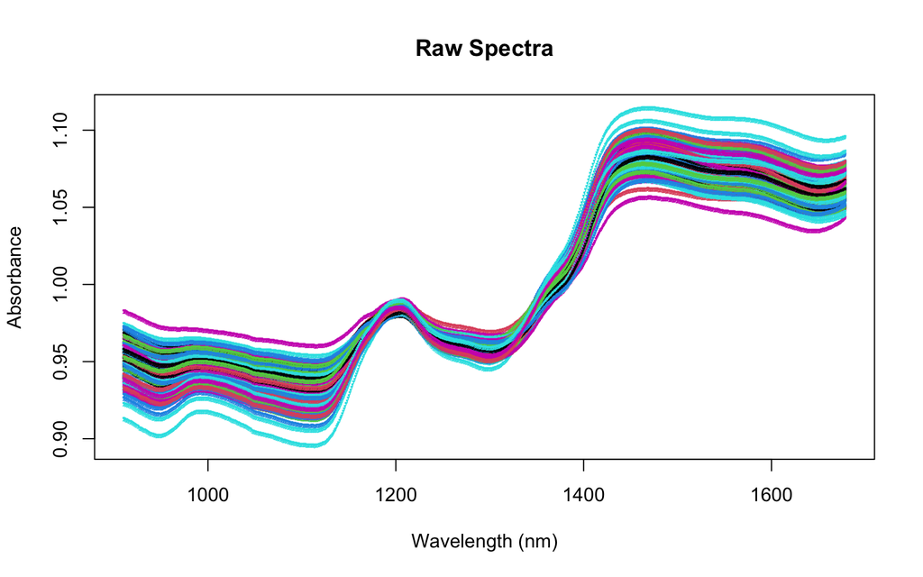

```r
## Transforming data for the next steps
NIRS_2020= NIRS%>%filter(year=="2020")  # Selecting a specific year
NIRS_matrix= as.matrix(NIRS_2020[,c(4:773)])
row.names(NIRS_matrix)= NIRS_2020$genotype

#### Plotting raw spectra
wavelengths<-seq(910,1679,by=1)
matplot(wavelengths,t(NIRS_matrix),lty=1,pch=","
        ,xlab="Wavelength (nm)",ylab="Absorbance",
        main="Raw Spectra"
)
```

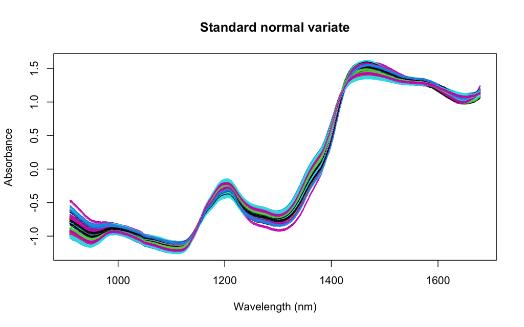

```r
#### Standard normal variate (center and scale)
NIRS_SNV=t(scale(t(NIRS_matrix)))
matplot(wavelengths,t(NIRS_SNV),lty=1,pch=","
        ,xlab="Wavelength (nm)",ylab="Absorbance",
        main="Standard normal variate"
)
```

```r
### 1st derivative
NIRS_SNV_1D <- savitzkyGolay(NIRS_SNV, m=1, p=2, w=37)
dim(NIRS_SNV)
```

```
## [1]  90 770
```

```r
dim(NIRS_SNV_1D) ## the savitzkyGolay remove waveleanghts from the borders
```

```
## [1]  90 734
```

```r
colnames(NIRS_SNV_1D[,c(1,734)])
```

```
## [1] "X928"  "X1661"
```

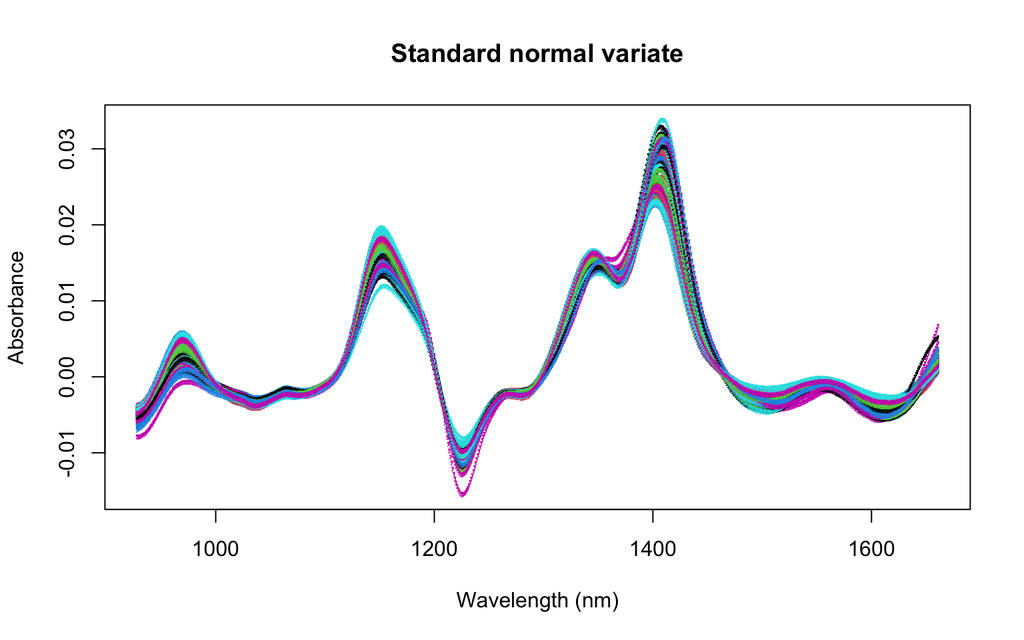

```r
matplot(928:1661,t(NIRS_SNV_1D),lty=1,pch=","
        ,xlab="Wavelength (nm)",ylab="Absorbance",
        main="Standard normal variate"
)
```

```r
## Same process for the other year
## Transforming data for the next steps
NIRS_2019= NIRS%>%filter(year=="2019")
NIRS_matrix= as.matrix(NIRS_2019[,c(4:773)])
row.names(NIRS_matrix)= NIRS_2019$genotype
#### Standard normal variate (center and scale)
NIRS_SNV.2=t(scale(t(NIRS_matrix)))
### 1st derivative
NIRS_SNV_1D.2 <- savitzkyGolay(NIRS_SNV.2, m=1, p=2, w=37)
```

## Exploring the data

### Estimate the variance components

Considering each wavelength as a trait, incorporating a fixed effect of year in which kernels were harvested and a random effect for genotype by year interaction to estimate the variance components for each wavelength.

```r
# Creating objects to store the values
GenomicVariance = rep(NA, 734)
GxeVariance= rep(NA, 734)
ResidualVariance= rep(NA, 734)
```

```r
##loop for all the wavelengths
for (i in 1:734) {
  Nirs.data= data.frame(NIRS[,c("genotype","year")],trait= rbind(NIRS_SNV_1D,NIRS_SNV_1D.2)[,i])
  #blup
  model <- mmer(trait~ year,
                random = ~genotype+ genotype:year,
                rcov= ~ units,
                data =Nirs.data)
  GenomicVariance[i] <- summary(model)$varcomp[1,1]
  GxeVariance[i] <- summary(model)$varcomp[2,1]
  ResidualVariance[i] <- summary(model)$varcomp[3,1]
}
```

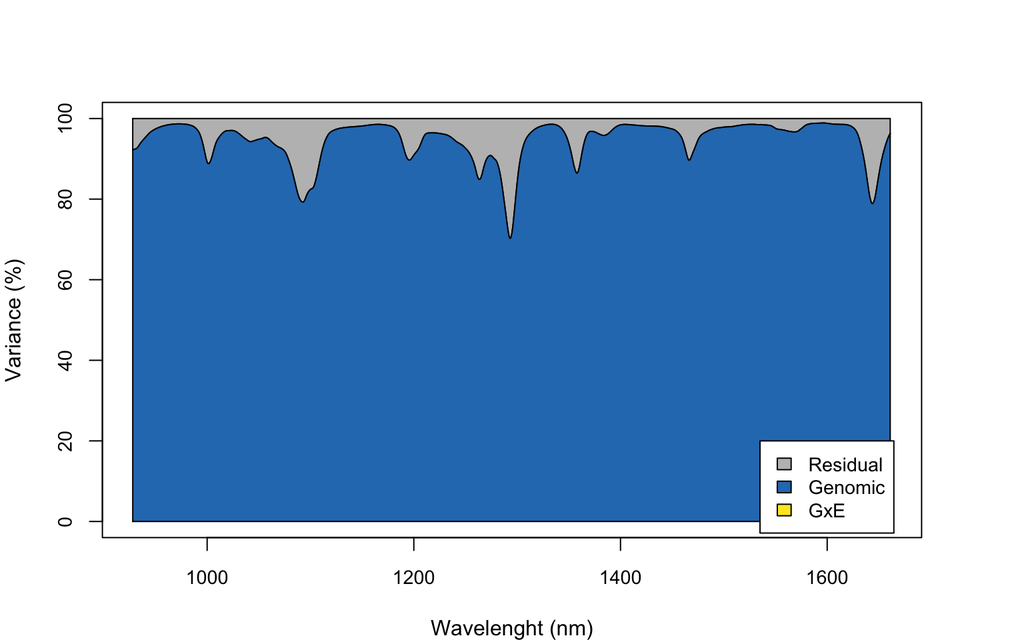

```r
##getting as proportion
PropGenomicVariance <- GenomicVariance/(GenomicVariance+GxeVariance+ResidualVariance)*100
PropGxEVariance <- GxeVariance/(GenomicVariance+GxeVariance+ResidualVariance)*100

##plot the variance
par(mar=c(4, 4, 4, 4))
plot(seq(928,1661,by=1), PropGenomicVariance, type="l", xlab="Wavelenght (nm)",
     xlim=c(928, 1662), ylim=c(0, 100), ylab="Variance (%)",cex.axis=0.9 )
polygon(c(928, seq(928,1661,by=1), 1661), c(100, PropGenomicVariance, 100), col = "grey")
#polygon(c(928, seq(928,1661,by=1), 1661),c(0, PropGenomicVariance + PropGxEVariance, 0), col = "#fde725ff")
polygon(c(928, seq(928,1661,by=1), 1661), c(0, PropGenomicVariance, 0), col = "#2a7bbeff")
legend(1535, 20, c("Residual", "Genomic", "GxE"), lty = 0, fill = c("grey", "#2a7bbeff",  "#fde725ff"), cex=0.9)
```

### Principal components analysis (PCA)

Estimation of principal components using both skNIR data and marker data.

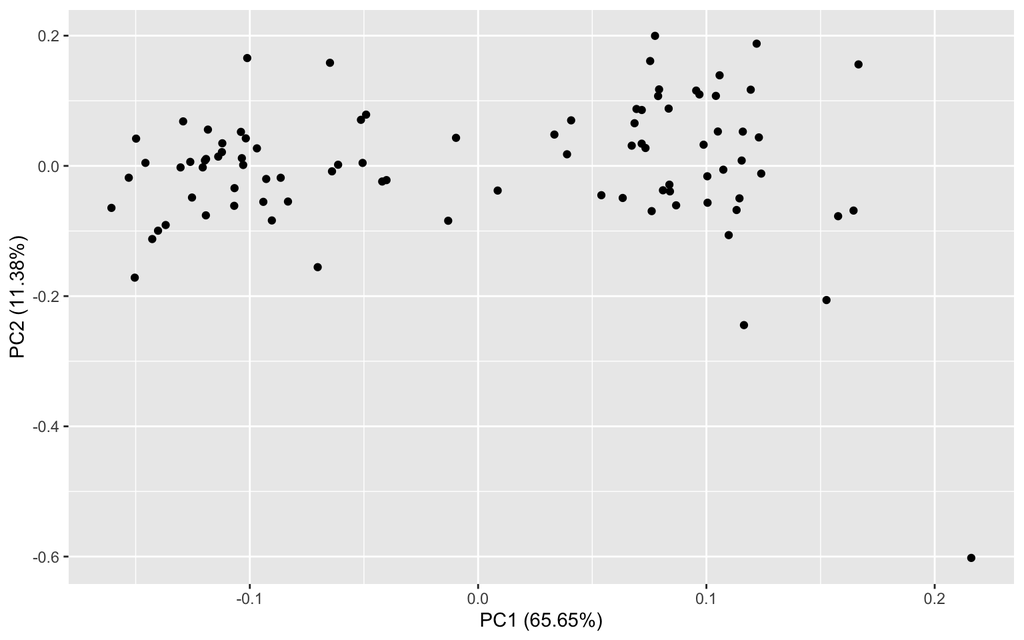

```r
## Performing PCA analysis
PCA_nirs <- prcomp(NIRS_SNV_1D,scale= T)  #scale the columns
#plot
autoplot(PCA_nirs)
```

Using markers:

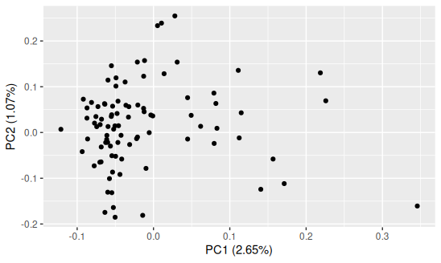

PCA using NIRS data showed a higher explained variance in the first two components. The molecular markers did not delineate distinct clusters, but PC1 of the skNIR analysis separated two clusters. Let’s check where the su1 and sh2 individuals are located.

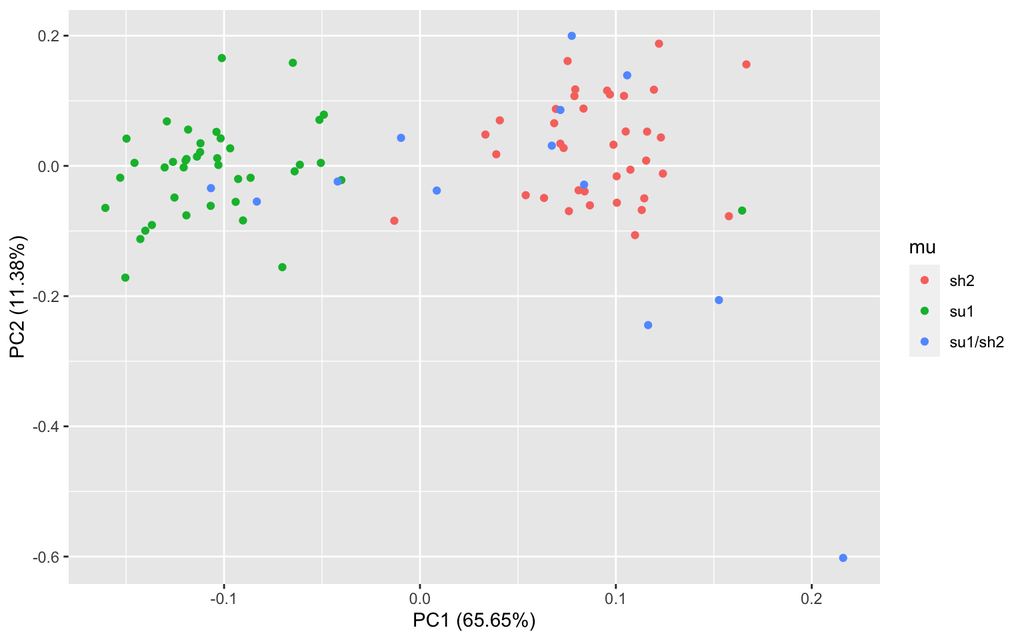

```r
autoplot(PCA_nirs, x=1, y=2,colour="mu", data=NIRS_2020 ) ## checking su1 and sh2 individuals
```

Markers:

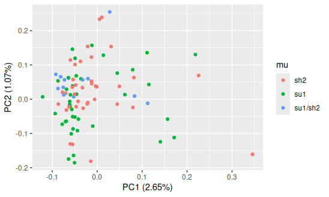

### Correlation with traits

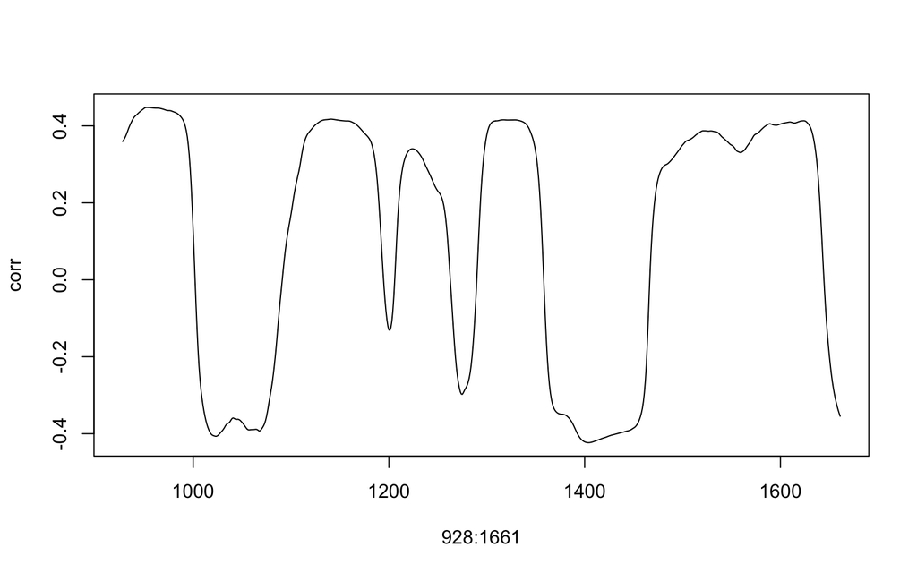

```r
## For all wavelengths
corr=rep(NA, 734)
for (i in 1:734) {
  corr[i]= cor(NIRS_SNV_1D[,i],Blues$PH, use="complete")
}

plot(x=928:1661, y=corr, type="l")
```

## Computing relationship matrix

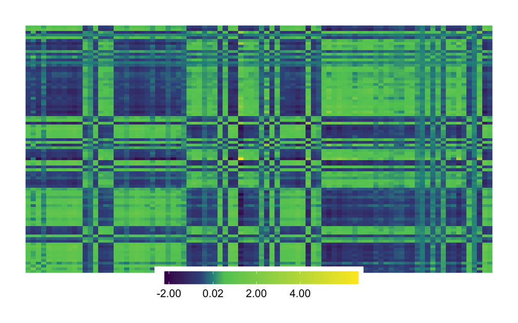

```r
###Phenomic
NIRS_SNV_1D= scale(NIRS_SNV_1D, center=T, scale=T) # scale absorbance at each wavelength
P_matrix<- tcrossprod(NIRS_SNV_1D)/ncol(NIRS_SNV_1D) ##computing the matrix
superheat(P_matrix , left.label = "none", bottom.label = "none")
```

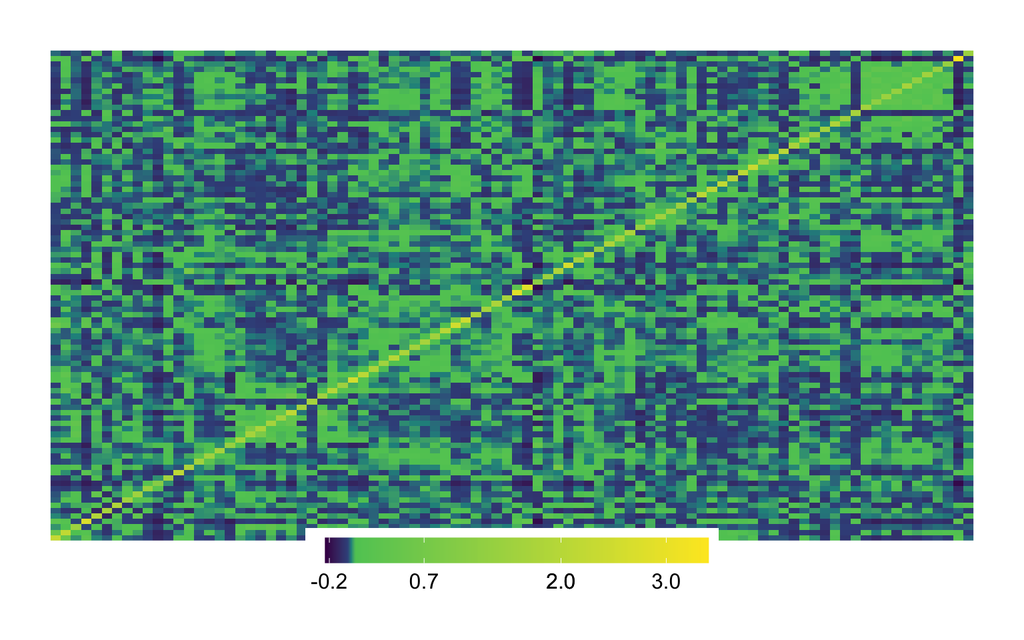

```r
##Comparing with genomic
superheat(G_mat, left.label = "none", bottom.label = "none")
```

## Prediction model

The GBLUP two-stage, using the BLUEs, follows:

$$y = \mu + Zg + e$$

where:

- $y$ is the vector of BLUEs,
- $\mu$ is the overall mean,
- $g$ is the vector of genotype effects (assumed to be random), where $g \sim N(0, G\sigma^2_g)$,
- $G$ is a matrix that describes the genomic similarities between pairs of genotypes, and $\sigma^2_g$ represents the genetic variance,
- $e$ is the vector of residuals (random), where $e \sim N(0, \sigma^2_{res})$, and $\sigma^2_{res}$ is the residual variance.

The $Z$ refer to the incidence matrices for $g$, respectively.

The same model used for genomic prediction is also used for phenomic prediction. Therefore, the genomic relationship matrix ($G$) is replaced by the phenomic relationship matrix ($P$).

```r
Blues$Genotype= as.factor(Blues$Genotype)
##PBlup
mod1 = mmer(Germ~ 1,
            random = ~vsr(Genotype,Gu=P_matrix),
            rcov= ~ units,
            data =Blues)
```

[output not shown]

```r
y_pred_set<-mod1$U$`u:Genotype`$Germ
cor(y_pred_set,Blues$Germ,use="complete")
```

```
## [1] 0.662155
```

### Cross-validation

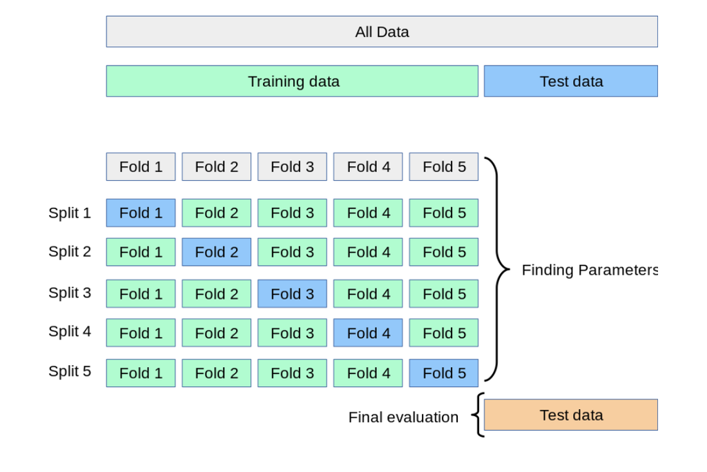

source:https://scikit-learn.org/stable/modules/cross_validation.html

```r
### parameters
n_id = length(Blues$Genotype)
n_model = 2 ## number of models
s=10  #reps for the cross validation

# Creating objects to store the values
y_pred_PS = matrix(NA,n_id,s)
y_pred_GS = matrix(NA,n_id,s)
corr= matrix(NA,s,n_model)
colnames(corr)=c("PS","GS")


##Lopping using cross-validation
for(k in 1:s){
  ## Sets: ####
  set.seed(200+k)                      # Setting the seed
  cv= kfold(n_id, k=5)                # Obtaining cross-validation subset for each fold

  ## Models: ####
  for(i in 1:5){  ##for all sets

    ### defining test and training population
    data= Blues
    data$Germ[cv==i]= NA

    ##PS
    mod1 = mmer(Germ~ 1,
                random = ~vsr(Genotype,Gu=P_matrix),
                rcov= ~ units,
                data =data)
    y_pred_set<-mod1$U$`u:Genotype`$Germ
    y_pred_PS[which(cv==i),k] = y_pred_set[which(cv==i)] # getting prediction for testing population


    ## Genomic
    mod2 = mmer(Germ~ 1,
                random = ~vsr(Genotype,Gu=G_mat),
                rcov= ~ units,
                data =data)
    y_pred_set<-mod2$U$`u:Genotype`$Germ
    y_pred_GS[which(cv==i),k] = y_pred_set[which(cv==i)] # getting prediction for testing population

  }


  ## accuracy
  corr[k,1] = cor(y_pred_PS[,k],Blues$Germ,use="complete")
  corr[k,2] = cor(y_pred_GS[,k],Blues$Germ,use="complete")
}
```

## Results

```r
# Calculating the accuracy for each model
colMeans(corr)
```

```
##        PS        GS
## 0.5920730 0.5511528
```

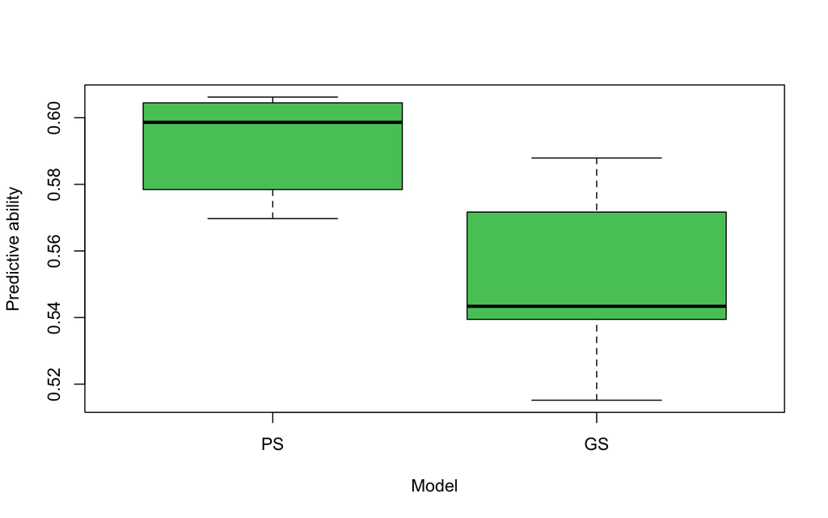

```r
## plotting
boxplot(corr,
        xlab="Model",
        ylab="Predictive ability",
        col="#56c667ff",)
```

[figure not shown]

```r
plot(corr[,2], corr[,1],
     xlim = c(0, 0.5), ylim = c(0, 0.5),
     xlab = "GBLUP",
     ylab = "PBLUP")
abline(a = 0, b = 1)
```

## References

Hu Y, Colantonio V, Müller BSF, et al (2021) Genome assembly and population genomic analysis provide insights into the evolution of modern sweet corn. Nat Commun 12:1227. https://doi.org/10.1038/s41467-021-21380-4

Rincent R, Charpentier J-P, Faivre-Rampant P, et al (2018) Phenomic Selection Is a Low-Cost and High-Throughput Method Based on Indirect Predictions: Proof of Concept on Wheat and Poplar. G3 Genes|Genomes|Genetics 8:3961-3972. https://doi.org/10.1534/g3.118.200760

Robert P, Brault C, Rincent R, Segura V (2022) Phenomic Selection: A New and Efficient Alternative to Genomic Selection. In: Ahmadi N, Bartholomé J (eds) Genomic Prediction of Complex Traits: Methods and Protocols. Springer US, New York, NY, pp 397-420

VanRaden PM (2008) Efficient Methods to Compute Genomic Predictions. Journal of Dairy Science 91:4414-4423. https://doi.org/10.3168/jds.2007-0980